# Communicate-Data-Finding-Slide-Deck-with-Ford-GoBike-System-Data

## Investigation Overview

> What are the features affecting trip duration the most ( weather , user type )

## Dataset Overview

> This data set includes information about individual rides made in a bike-sharing system covering the greater San Francisco Bay area.

```python
# import all packages and set plots to be embedded inline
import numpy as np
import pandas as pd
import matplotlib.pyplot as plt
import seaborn as sb
import os
%matplotlib inline

# suppress warnings from final output
import warnings
warnings.simplefilter("ignore")
```

## (Visualization 1)

> Question 1 : What is the distribution of trip duration?

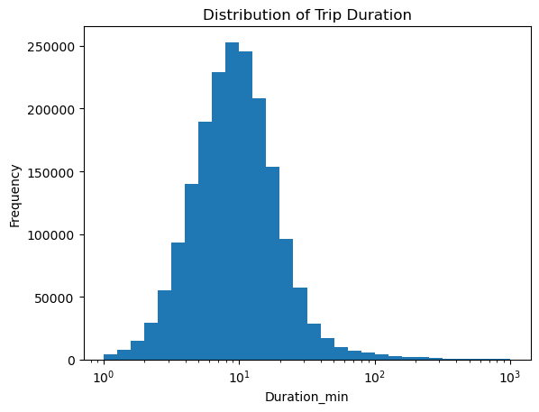

```python
# Let's plot the distribution of trip duration.
# change the trip duration unit from second to min
df_bike_copy['duration_min'] = df_bike_copy['duration_sec'] / 60
df_bike_copy.drop('duration_sec' , axis = 1 , inplace = True)

bin_edges = 10**np.arange(0 , 3+0.1 , 0.1)
ticks =  [ 0.1 , 0.3 , 1 , 3, 10, 30, 100, 300]
labels = ['{}'.format(v) for v in ticks]
plt.hist(data = df_bike_copy , x = 'duration_min' , bins = bin_edges);
plt.xticks(ticks,labels);
plt.xlabel('Duration_min');
plt.xscale('log');
plt.title('Distribution of Trip Duration')
plt.ylabel('Frequency')
```

> Conclusion 1 : We can see from the distribution , the trip duration of most users is about 10 mins

## (Visualization 2)

> Question 2. Does weather(month) affect the trip duration ?

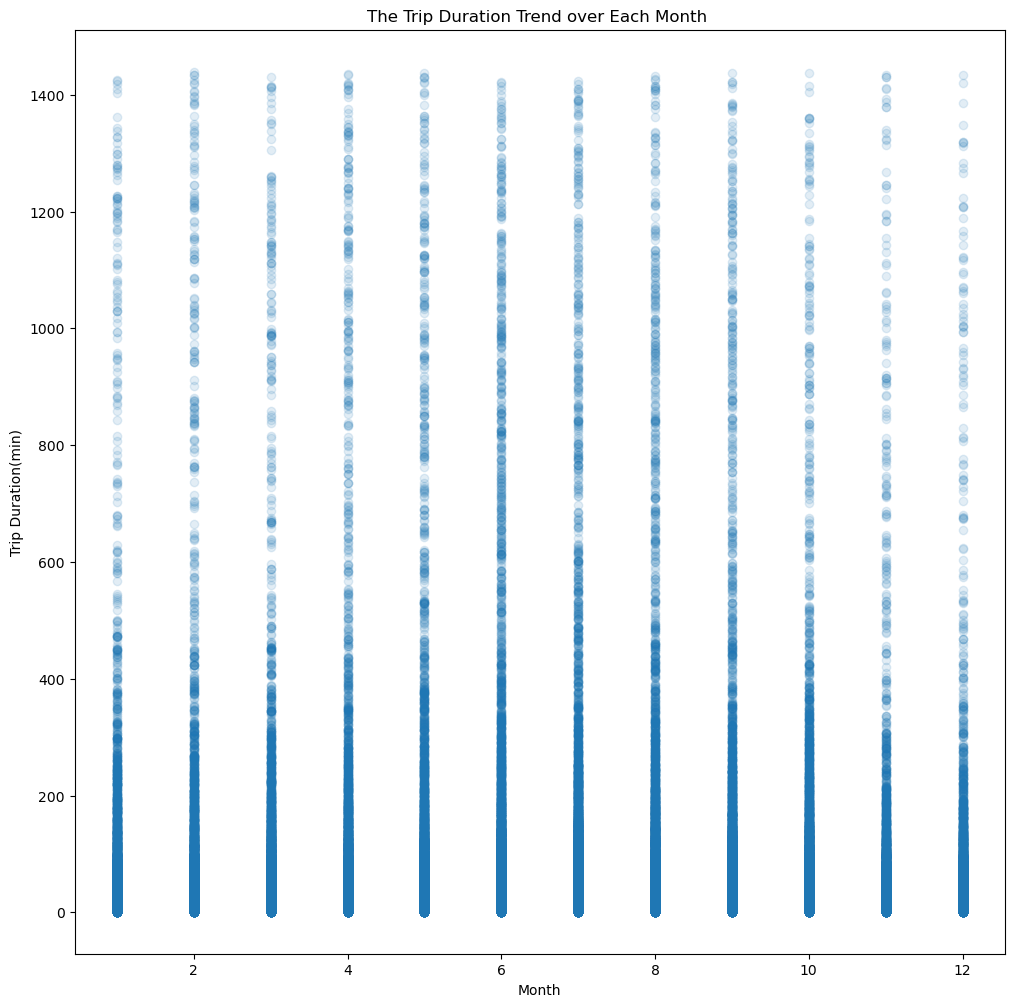

```python
df_bike_copy['month_start'] = pd.DatetimeIndex(df_bike_copy['start_time']).month
# We can check the trip duration over changes over each month.
plt.figure(figsize = [12,12])
plt.scatter(data = df_bike_copy , x = 'month_start' , y = 'duration_min' , alpha = 1/8 )
plt.title('The Trip Duration Trend over Each Month ')
plt.xlabel('Month')
plt.ylabel('Trip Duration(min)')
```

> Question 3. Do seasons have a more significant effect the trip duration ?

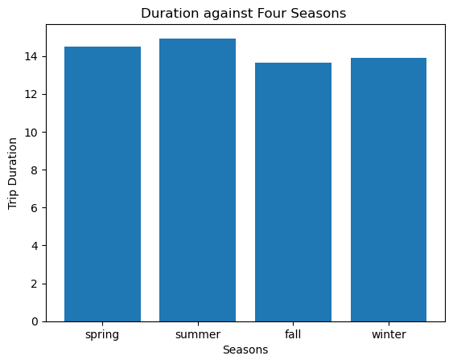

```python
# Create 4 season categories
spring_dur = df_bike_copy.query('month_start in [3, 4, 5]')['duration_min'].mean()
summer_dur = df_bike_copy.query('month_start in [6, 7, 8]')['duration_min'].mean()
fall_dur = df_bike_copy.query('month_start in [9, 10, 11]')['duration_min'].mean()
winter_dur = df_bike_copy.query('month_start in [12, 1, 2]')['duration_min'].mean()

plt.bar(['spring','summer','fall','winter'],[spring_dur , summer_dur , fall_dur , winter_dur] )
plt.title('Duration against Four Seasons ')
plt.xlabel('Seasons')
plt.ylabel('Trip Duration');
```

> Conclusion 2 : weather has some affect over the trip duration but the influence is very limited. Summer and Spring have relatively higher trip duration. Fall turns to have the lowest trip duration. After investigation, I found in the fall of 2018 there was a wildfire in California, which caused the worst air quality in San Francisco. It is very likely that people tend to do less outdoor activities due to the pool air quality.

## (Visualization 3)

Question 4 : Does user type lead to the lower trip duration?

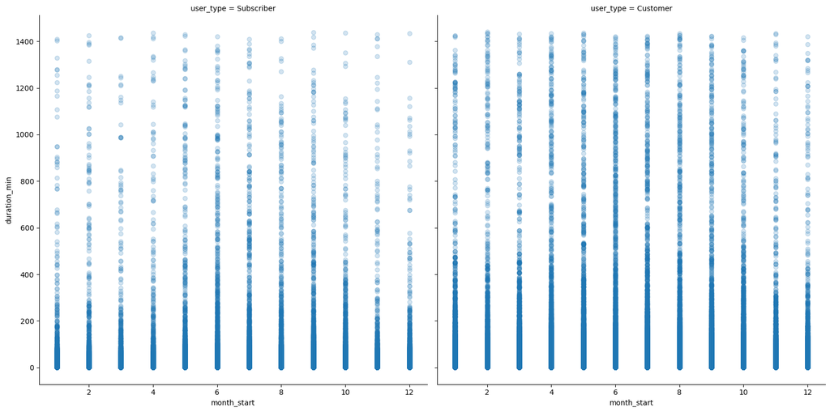

```python
m = sb.FacetGrid(data =  df_bike_copy, col = 'user_type', size = 8, col_wrap = 2)
m.map(sb.regplot, 'month_start', 'duration_min', y_jitter = 0.04, fit_reg = False,scatter_kws = {'alpha' : 1/5});
```

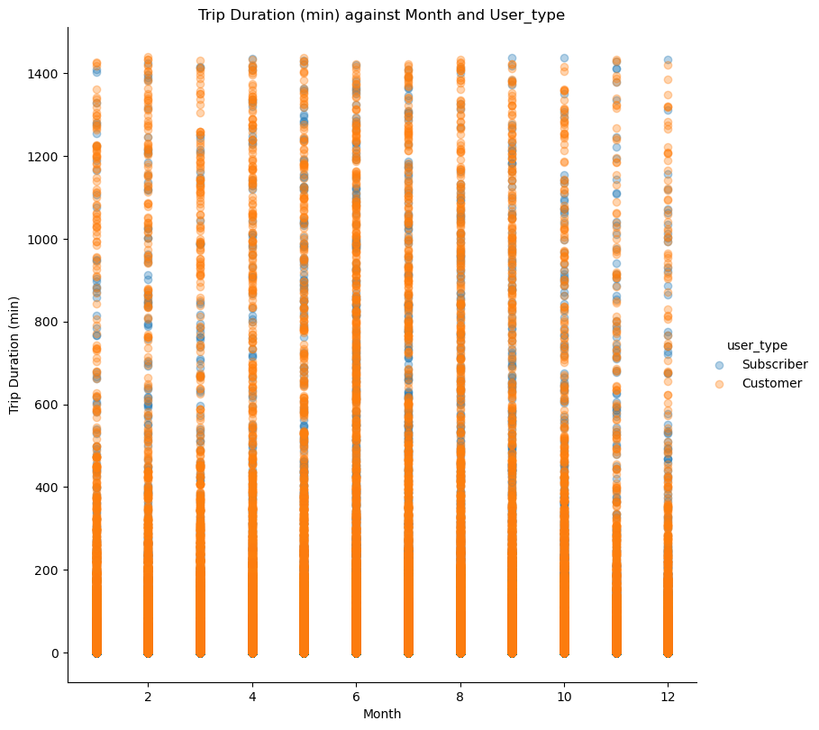

```python
# I want to find out if user type lead to the lower trip duration
g = sb.FacetGrid(data=df_bike_copy, hue='user_type', height=8)
g.map(plt.scatter, 'month_start', 'duration_min', alpha=1/3)
g.add_legend()

plt.title('Trip Duration (min) against Month and User_type')
plt.xlabel('Month')
plt.ylabel('Trip Duration (min)')

plt.show()
```